[← Back to All Parables](https://www.kameronyork.com/parables/)

# Drawing in the Net

by Kameron York

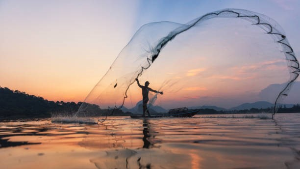

#### Reference:

[Matthew 13:47-50](https://www.churchofjesuschrist.org/study/scriptures/nt/matt/13?lang=eng&id=47-50#p47)

#### What is the Parable of Drawing in the Net About?

The parable of drawing in the net occurs immediately after the parables of the pearl and hidden treasure. In this parable Jesus relates the kingdom of heaven to a fisher’s net that gathered every kind of fish. This gathering is because a net cannot choose what is in its path. Then, when the fisherman has pulled the net ashore they will separate the good from the bad.

Unlike most parables Jesus gave the meaning behind this story. The net represents the second coming of Christ, in which everyone will be caught up and the righteous will be separated from the wicked on the day of Judgement.

#### What are the Symbols of the Parable of Drawing in the Net?

**The Net** - The second coming. The net is meant to represent the totality of Christ’s judgement. **The Fisherman** - The Lord. This is because the fisherman is the judge of good and bad, and Jesus is the only one with the authority to judge. **Good Fish** - The righteous in the world. **Bad Fish** - The wicked in the world. **Vessels** - The presence of God. **Fire** - Anywhere outside of the presence of God.

#### What do Modern Prophets and Apostles say about Drawing in the Net?

As of today the only modern apostle to mention, “Drawing in the Net,” is Elder Neal A. Maxwell. This parable is used as a footnote in two of his General Conference talks, however the reference to drawing in a net is unrelated to the Second Coming. Elder Maxwell references drawing in the net in terms of missionaries who are meant to convert people from all walks of life. These missionary efforts are meant to draw in a net of all kinds of converts for the Lord. This meaning is different from the explanation given by Jesus, but that’s alright. Part of the beauty of parables and their meanings is their subjectivity. While parables have a specific meaning there are so many other ways the parable can be interpreted. Because of this principle a parable can have countless meanings. One of the meanings of the net is missionary work. Another meaning is gathering for judgement at the second coming of Jesus Christ.